# 市场观察

2016/11/01

## 一、指数估值

### (一)指数动态市盈率

核心指数成分股的动态市盈率中位数走势如下图所示：

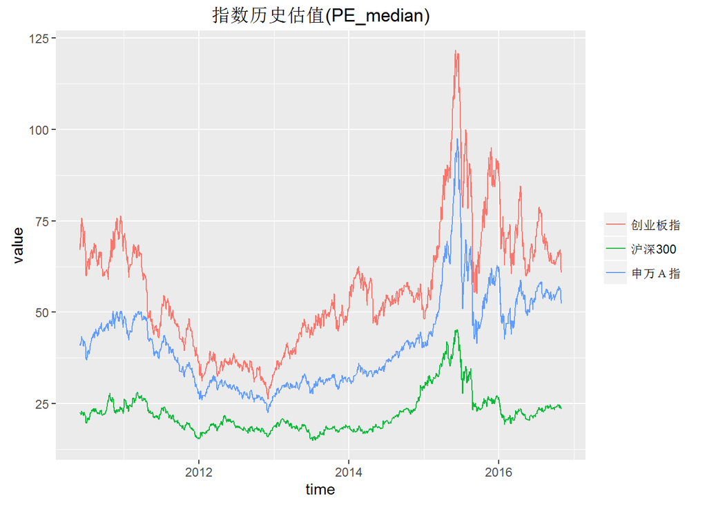

### (二)指数动态市盈率百分位

核心指数上述数据的百分位走势如下图所示：

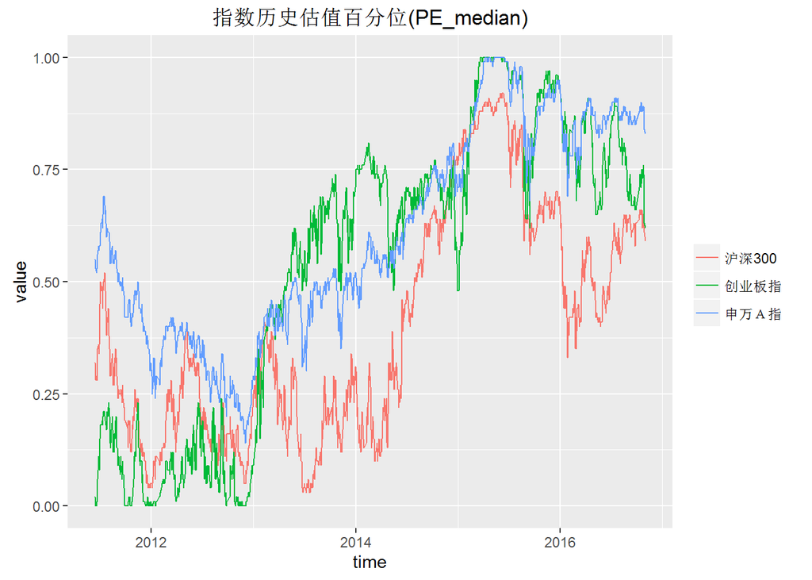

### (三)指数估值概览

纳入观察的18只指数最新的估值情况如下表：

| 日期 | 指数代码 | 指数简称 | 动态市盈率 | 上周动态市盈率 | 市盈率百分位 | 上周市盈率百分位 | 动态市净率 | 市净率百分位 |
| --- | --- | --- | --- | --- | --- | --- | --- | --- |
| 2016-10-31 | EI000805 | A股资源 | 60.41 | 59.23 | 0.96 | 0.95 | 2.33 | 0.44 |
| 2016-10-31 | EI000979 | 大宗商品 | 46.03 | 53.19 | 0.88 | 0.98 | 2.43 | 0.39 |
| 2016-10-31 | EI000808 | 医药生物 | 44.68 | 42.87 | 0.85 | 0.80 | 4.65 | 0.26 |
| 2016-10-31 | EI000933 | 中证医药 | 43.48 | 42.51 | 0.84 | 0.81 | 3.98 | 0.07 |
| 2016-10-31 | EI801003 | 申万Ａ指 | 52.35 | 56.49 | 0.83 | 0.89 | 4.31 | 0.64 |
| 2016-10-31 | EI399005 | 中小板指P | 44.68 | 47.50 | 0.78 | 0.84 | 4.75 | 0.47 |
| 2016-10-31 | EI000819 | 有色金属 | 50.25 | 64.46 | 0.74 | 0.88 | 3.43 | 0.63 |
| 2016-10-31 | EI399330 | 深证100 | 34.29 | 36.61 | 0.74 | 0.82 | 3.95 | 0.60 |
| 2016-10-31 | EI399959 | 军工指数 | 89.56 | 91.75 | 0.72 | 0.76 | 5.15 | 0.63 |
| 2016-10-31 | EI000934 | 中证金融 | 19.30 | 18.94 | 0.65 | 0.63 | 1.96 | 0.31 |
| 2016-10-31 | EI399006 | 创业板指 | 60.88 | 66.69 | 0.62 | 0.75 | 6.20 | 0.52 |
| 2016-10-31 | EI000300 | 沪深300 | 23.50 | 24.40 | 0.59 | 0.65 | 2.40 | 0.40 |
| 2016-10-31 | EI000905 | 中证500 | 38.20 | 38.92 | 0.58 | 0.61 | 3.22 | 0.44 |
| 2016-10-31 | EI000998 | 中证TMT | 47.96 | 58.33 | 0.56 | 0.75 | 4.62 | 0.43 |
| 2016-10-31 | EI000827 | 中证环保 | 37.96 | 39.90 | 0.48 | 0.57 | 3.12 | 0.29 |
| 2016-10-31 | EI000016 | 上证50 | 15.92 | 17.28 | 0.45 | 0.57 | 1.50 | 0.05 |
| 2016-10-31 | EI801120 | 申万食品饮料 | 37.21 | 38.95 | 0.42 | 0.48 | 4.57 | 0.61 |
| 2016-10-31 | EI000932 | 中证消费 | 30.09 | 30.91 | 0.32 | 0.39 | 3.74 | 0.20 |

## 二、基差

### (一)基差走势

三大股指期货隔季合约基差走势如下图：

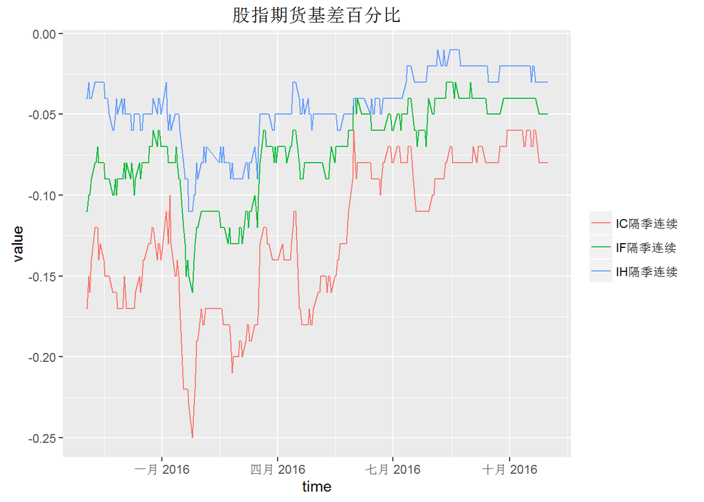

### (二)基差概况

三大股指期货连续合约基差概况如下表：

| 日期 | 合约简称 | 合约收盘价 | 基差 | 基差百分比 | 上周基差 | 上周基差百分比 |
| --- | --- | --- | --- | --- | --- | --- |
| 2016-10-31 | IH当月连续 | 2242.8 | -7.67 | 0.00 | -12.15 | -0.01 |
| 2016-10-31 | IH下月连续 | 2234.0 | -16.47 | -0.01 | -20.75 | -0.01 |
| 2016-10-31 | IH下季连续 | 2205.8 | -44.67 | -0.02 | -46.35 | -0.02 |
| 2016-10-31 | IH隔季连续 | 2177.8 | -72.67 | -0.03 | -65.15 | -0.03 |
| 2016-10-31 | IF当月连续 | 3317.4 | -18.88 | -0.01 | -23.38 | -0.01 |
| 2016-10-31 | IF下月连续 | 3293.6 | -42.68 | -0.01 | -43.58 | -0.01 |
| 2016-10-31 | IF下季连续 | 3226.0 | -110.28 | -0.03 | -111.38 | -0.03 |
| 2016-10-31 | IF隔季连续 | 3164.0 | -172.28 | -0.05 | -151.98 | -0.05 |
| 2016-10-31 | IC当月连续 | 6407.6 | -44.61 | -0.01 | -68.07 | -0.01 |
| 2016-10-31 | IC下月连续 | 6335.6 | -116.61 | -0.02 | -145.47 | -0.02 |
| 2016-10-31 | IC下季连续 | 6128.2 | -324.01 | -0.05 | -362.87 | -0.06 |
| 2016-10-31 | IC隔季连续 | 5951.8 | -500.41 | -0.08 | -531.27 | -0.08 |

## 三、套利

### (一)复牌股票套利

近两天复牌股票套利情况如下表：

[1] “无复牌股票套利”

### (二)定增基金跟踪

截止2016-11-01定增基金数据如下表，明细数据参见钱瀚的模板。

| 代码 | 名称 | 到期日期 | 最新净值 | 昨日收盘价 | 折溢价率 | 整体隐含折价率 | 大盘回撤0.1净值回撤 |
| --- | --- | --- | --- | --- | --- | --- | --- |
| 168101.OF | 九泰锐智 | 20200814 | 1.44 | 1.35 | -0.06 | 0.07 | -0.06 |
| 168102.OF | 九泰锐富 | 20210204 | 1.03 | 0.99 | -0.04 | 0.03 | -0.03 |
| 161225.OF | 国投瑞盈 | 20161119 | 1.05 | 1.03 | -0.01 | 0.00 | -0.08 |
| 501001.OF | 财通精选 | 20170101 | 1.07 | 1.03 | -0.04 | 0.00 | -0.09 |
| 501015.OF | 财通升级 | 20170908 | 1.04 | 1.00 | -0.05 | 0.09 | -0.06 |
| 160518.OF | 博时睿远 | 20171016 | 1.01 | 0.99 | -0.02 | 0.07 | -0.03 |

定增基金近期的净值走势如下图：

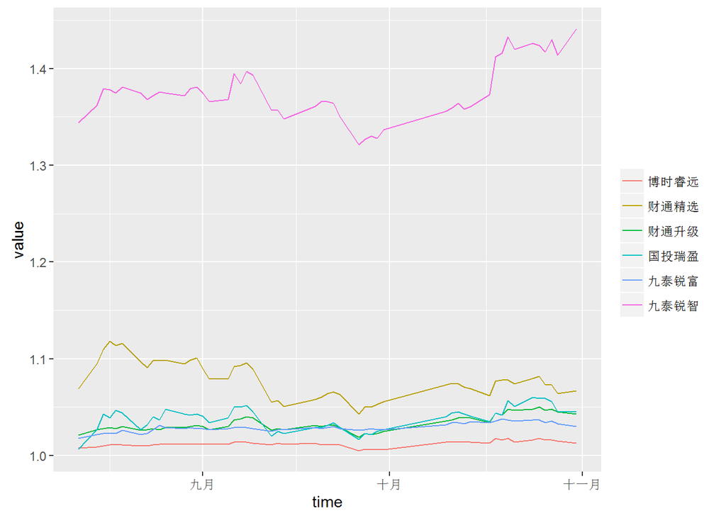

定增基金近期的折溢价走势如下图：

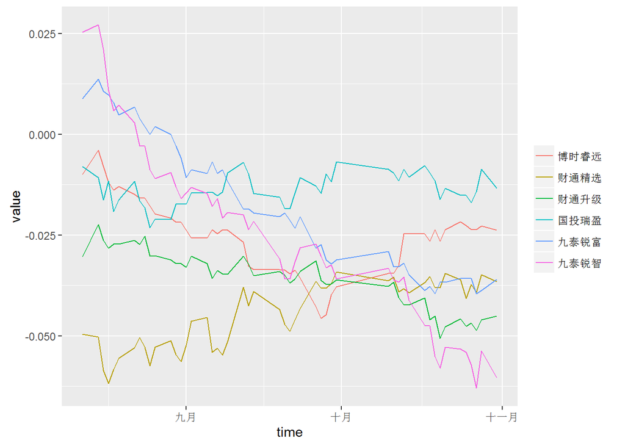

## 四、择时

### (一)大盘均线强弱指数

大盘均线强弱指数在一定程度上可以视为一个反转指标，当大盘均线得分接近8分时，预示市场接近顶部，当大盘均线得分接近0分时，预示市场接近底部。  
大盘均线强弱指数近一年来走势如下图：

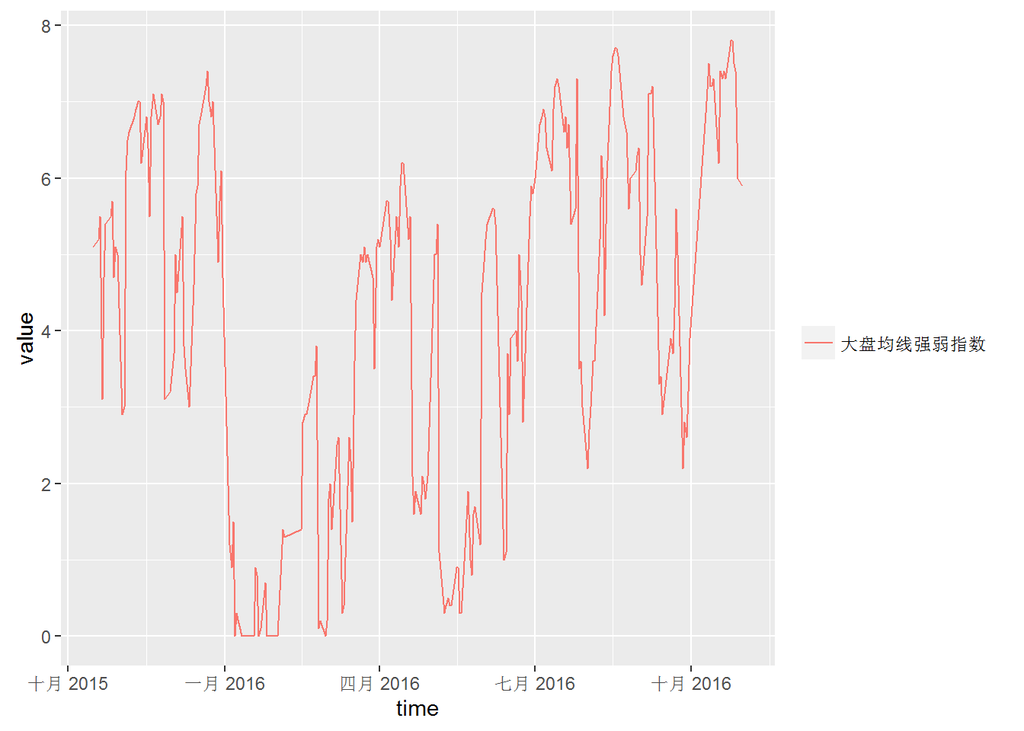

申万一级行业的最新得分及上周得分见下表：

| 日期 | 指数代码 | 指数名称 | 最新值 | 上周值 |
| --- | --- | --- | --- | --- |
| 2016-10-31 | EI801020 | 申万采掘 | 8 | 8 |
| 2016-10-31 | EI801120 | 申万食品饮料 | 8 | 8 |
| 2016-10-31 | EI801710 | 申万建筑材料 | 8 | 8 |
| 2016-10-31 | EI801790 | 申万非银金融 | 8 | 8 |
| 2016-10-31 | EI801050 | 申万有色金属 | 7 | 7 |
| 2016-10-31 | EI801110 | 申万家用电器 | 7 | 8 |
| 2016-10-31 | EI801130 | 申万纺织服装 | 7 | 8 |
| 2016-10-31 | EI801880 | 申万汽车 | 7 | 8 |
| 2016-10-31 | EI801010 | 申万农林牧渔 | 6 | 8 |
| 2016-10-31 | EI801030 | 申万化工 | 6 | 8 |
| 2016-10-31 | EI801040 | 申万钢铁 | 6 | 8 |
| 2016-10-31 | EI801080 | 申万电子 | 6 | 8 |
| 2016-10-31 | EI801140 | 申万轻工制造 | 6 | 8 |
| 2016-10-31 | EI801150 | 申万医药生物 | 6 | 8 |
| 2016-10-31 | EI801160 | 申万公用事业 | 6 | 8 |
| 2016-10-31 | EI801180 | 申万房地产 | 6 | 8 |
| 2016-10-31 | EI801200 | 申万商业贸易 | 6 | 8 |
| 2016-10-31 | EI801210 | 申万休闲服务 | 6 | 8 |
| 2016-10-31 | EI801230 | 申万综合 | 6 | 8 |
| 2016-10-31 | EI801720 | 申万建筑装饰 | 6 | 8 |
| 2016-10-31 | EI801730 | 申万电气设备 | 6 | 8 |
| 2016-10-31 | EI801780 | 申万银行 | 6 | 8 |
| 2016-10-31 | EI801890 | 申万机械设备 | 6 | 8 |
| 2016-10-31 | EI801170 | 申万交通运输 | 5 | 7 |
| 2016-10-31 | EI801770 | 申万通信 | 5 | 8 |
| 2016-10-31 | EI801750 | 申万计算机 | 4 | 7 |
| 2016-10-31 | EI801740 | 申万国防军工 | 2 | 7 |
| 2016-10-31 | EI801760 | 申万传媒 | 0 | 6 |

### (二)LLT及均线择时

LLT本质上是一个改进的单均线择时指标，较原始的均线择时延迟更低。  
择时模型和指数本身的净值走势如下图：

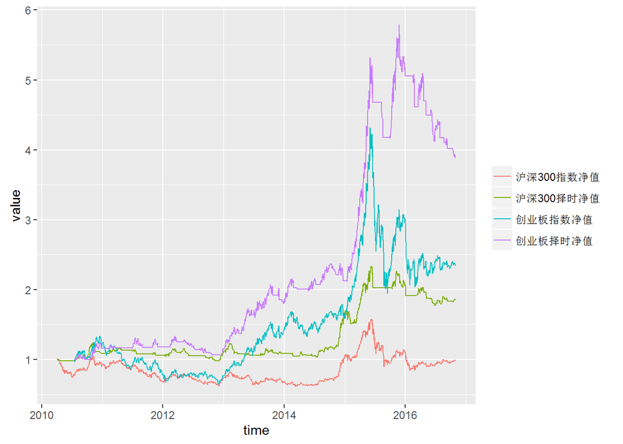

择时模型和指数的收益率统计如下表：

|  | 沪深300指 | 沪深300LLT | 创业板指 | 创业板MA |
| --- | --- | --- | --- | --- |
| 年化收益率 | 0.00 | 0.10 | 0.15 | 0.25 |
| 年化波动率 | 0.25 | 0.16 | 0.34 | 0.24 |
| 年化Sharpe值 | -0.01 | 0.63 | 0.44 | 1.06 |
| 最大回撤 | 0.47 | 0.24 | 0.55 | 0.33 |

择时模型最近10个交易日的信号如下表：

| 日期 | 沪深300收盘价 | 沪深300择时信号 | 创业板收盘价 | 创业板择时信号 |
| --- | --- | --- | --- | --- |
| 2016-10-18 | 3321.332 | hold | 2198.141 | buy |
| 2016-10-19 | 3316.241 | hold | 2184.910 | hold |
| 2016-10-20 | 3318.604 | hold | 2193.255 | hold |
| 2016-10-21 | 3327.740 | hold | 2180.996 | hold |
| 2016-10-24 | 3367.578 | hold | 2200.803 | hold |
| 2016-10-25 | 3367.455 | hold | 2200.207 | hold |
| 2016-10-26 | 3354.800 | hold | 2184.493 | hold |
| 2016-10-27 | 3345.695 | hold | 2182.477 | hold |
| 2016-10-28 | 3340.126 | hold | 2165.433 | sell |
| 2016-10-31 | 3336.278 | hold | 2159.760 |  |

### (三)网格交易

在经历了三轮股灾，A股逐步回归正常，在过去的一段时间呈现一个震荡的格局，如果未来没有增量信息，很可能维持震荡。结合股指期货的贴水，前期研究了一下网格交易。网格交易的结果如下图：

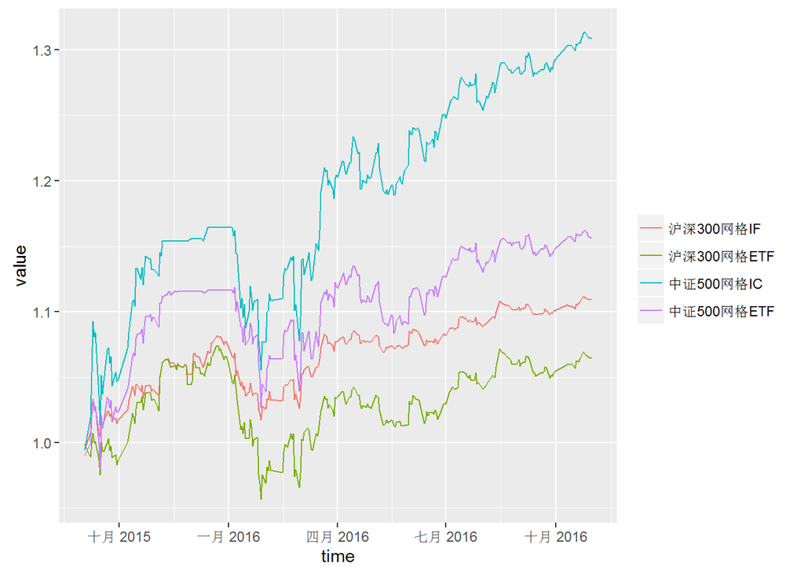

网格交易的收益统计如下表：

|  | 沪深300指数 | 沪深300网格IF | 沪深300网格ETF | 中证500指数 | 中证500网格IC | 中证500网格ETF |
| --- | --- | --- | --- | --- | --- | --- |
| 年化收益率 | -0.01 | 0.10 | 0.06 | 0.04 | 0.27 | 0.14 |
| 年化波动率 | 0.25 | 0.07 | 0.11 | 0.34 | 0.16 | 0.13 |
| 年化Sharpe值 | -0.03 | 1.35 | 0.53 | 0.12 | 1.75 | 1.11 |
| 最大回撤 | 0.26 | 0.06 | 0.11 | 0.33 | 0.09 | 0.08 |

### (四)银行股轮动

银行股轮动是参考集思录的热门贴银行股评级而来的，数据的提取和参数的设置和原贴有一定的差别，所以轮动的效果也会不太一样，不过回测的效果还不错，从现在开始跟踪。2012年以来银行股轮动的结果如下图：

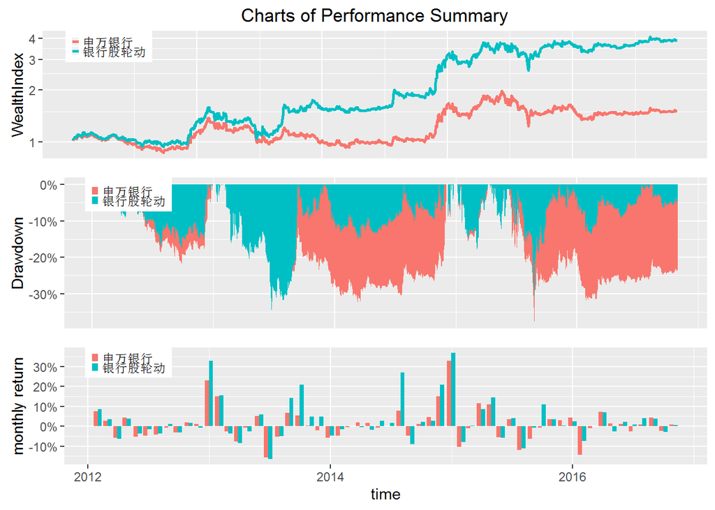

银行股轮动的收益统计如下表：

|  | 申万银行 | 银行股轮动 |
| --- | --- | --- |
| 2012-01-05 ~ 2012-12-31 | 0.14 | 0.31 |
| 2013-01-04 ~ 2013-12-31 | -0.10 | 0.20 |
| 2014-01-02 ~ 2014-12-31 | 0.61 | 1.02 |
| 2015-01-05 ~ 2015-12-31 | -0.03 | 0.17 |
| 2016-01-04 ~ 2016-10-31 | -0.06 | 0.05 |
| Cumulative Return | 0.51 | 2.89 |
| Annualized Return | 0.09 | 0.34 |

银行股轮动的最新得分如下表：

| 日期 | 代码 | 简称 | PB | 预期ROE | 翻倍期 | 持仓 |
| --- | --- | --- | --- | --- | --- | --- |
| 2016-10-31 | EQ601988 | 中国银行 | 0.74 | 0.12 | 3.48 | hold |
| 2016-10-31 | EQ601328 | 交通银行 | 0.74 | 0.11 | 3.63 |  |
| 2016-10-31 | EQ601818 | 光大银行 | 0.76 | 0.12 | 3.64 |  |
| 2016-10-31 | EQ601288 | 农业银行 | 0.81 | 0.13 | 3.91 |  |
| 2016-10-31 | EQ600015 | 华夏银行 | 0.86 | 0.15 | 3.96 |  |
| 2016-10-31 | EQ601398 | 工商银行 | 0.85 | 0.14 | 4.09 |  |
| 2016-10-31 | EQ601939 | 建设银行 | 0.88 | 0.14 | 4.24 |  |
| 2016-10-31 | EQ000001 | 平安银行 | 0.85 | 0.13 | 4.40 |  |
| 2016-10-31 | EQ601166 | 兴业银行 | 0.94 | 0.15 | 4.61 |  |
| 2016-10-31 | EQ600000 | 浦发银行 | 1.03 | 0.15 | 5.17 |  |
| 2016-10-31 | EQ601998 | 中信银行 | 0.90 | 0.12 | 5.26 |  |
| 2016-10-31 | EQ600016 | 民生银行 | 1.07 | 0.14 | 5.83 |  |
| 2016-10-31 | EQ600036 | 招商银行 | 1.19 | 0.15 | 6.18 |  |
| 2016-10-31 | EQ601009 | 南京银行 | 1.15 | 0.14 | 6.22 |  |
| 2016-10-31 | EQ601169 | 北京银行 | 1.21 | 0.14 | 6.89 |  |
| 2016-10-31 | EQ002142 | 宁波银行 | 1.37 | 0.15 | 7.13 |  |